# Practicum I / Design & Implement a Relational Database

### Author: Zihao Qiu

### Email: qiu.ziha@northeastern.edu

## 1. ERD Diagram

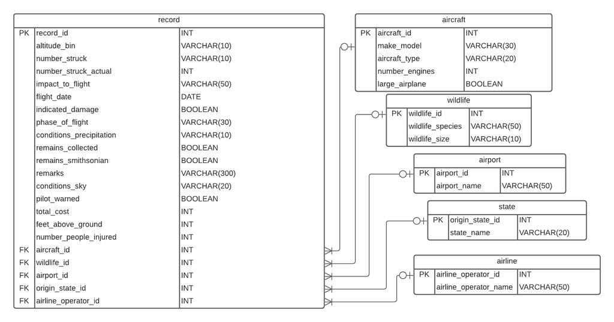

## 2. Define Relational Schema

### 2.1 Connect to the local MySQL server

```r
library(RMySQL)
db_user <- 'root'
db_password <- 'password'
db_name <- 'myDB'
db_host <- 'localhost'
db_port <- 3306
mydb <-  dbConnect(MySQL(), user = db_user, password = db_password,
                 dbname = db_name, host = db_host, port = db_port)
```

Note: all table and column names are normalized to meet the SQL convention, specifically lower cases and underscores.

### 2.2 The aircraft table and its definition

The reason for not using make_model as the primary key is that the same make_model may have different engines.

```sql
CREATE TABLE aircraft(
  aircraft_id INT,
  make_model VARCHAR(30),
  aircraft_type VARCHAR(20),
  number_engines INT,
  large_airplane BOOLEAN,
  PRIMARY KEY (aircraft_id)
);
```

### 2.3 The wilflife table and its definition

The wildlife_id field is an artificial primary key. There is no “AUTO INCREMENT” because it will be done in the R code chunk later.

```sql
CREATE TABLE wildlife(
  wildlife_id INT,
  wildlife_species VARCHAR(50),
  wildlife_size VARCHAR(10),
  PRIMARY KEY (wildlife_id)
);
```

### 2.4 The airport table and its definition

The airport table is a lookup table.

```sql
CREATE TABLE airport(
  airport_id INT,
  airport_name VARCHAR(50),
  PRIMARY KEY (airport_id)
);
```

### 2.5 The state table and its definition

The state table is a lookup table.

```sql
CREATE TABLE state(
  origin_state_id INT,
  state_name VARCHAR(20),
  PRIMARY KEY (origin_state_id)
);
```

### 2.6 The airline table and its definition

The airline table is a lookup table.

```sql
CREATE TABLE airline(
  airline_operator_id INT,
  airline_operator_name VARCHAR(50),
  PRIMARY KEY (airline_operator_id)
);
```

### 2.7 The record table and its definition

Naturally, the record id will be used as the table’s primary key.  
This table can be divided further, for example the phase_of_flight field can be divided into a look up table.

```sql
CREATE TABLE record(
  record_id INT,
  altitude_bin VARCHAR(10),
  number_struck VARCHAR(10),
  number_struck_actual INT,
  impact_to_flight VARCHAR(50),
  flight_date DATE,
  indicated_damage BOOLEAN,
  phase_of_flight VARCHAR(30),
  conditions_precipitation VARCHAR(10),
  remains_collected BOOLEAN,
  remains_smithsonian BOOLEAN,
  remarks VARCHAR(300),
  conditions_sky VARCHAR(20),
  pilot_warned BOOLEAN,
  total_cost INT,
  feet_above_ground INT,
  number_people_injured INT,
  aircraft_id INT,
  wildlife_id INT,
  airport_id INT,
  origin_state_id INT,
  airline_operator_id INT,
  PRIMARY KEY (record_id),
  FOREIGN KEY (aircraft_id) REFERENCES aircraft(aircraft_id),
  FOREIGN KEY (wildlife_id) REFERENCES wildlife(wildlife_id),
  FOREIGN KEY (airport_id) REFERENCES airport(airport_id),
  FOREIGN KEY (origin_state_id) REFERENCES state(origin_state_id),
  FOREIGN KEY (airline_operator_id) REFERENCES airline(airline_operator_id)
);
```

## 3. Load Data into R FROM CSV File

Note that column names were manually normalized.

```r
path <- "C:/Users/zqiu9/Documents/R Projects/"
fn <- "BirdStrikesData.csv"
fileName <- paste(path, fn, sep = "/")
birdDF <- read.csv(fileName, header = TRUE, col.names = c("record_id", "aircraft_type", "airport_name", "altitude_bin", "make_model", "number_struck", "number_struck_actual", "impact_to_flight", "flight_date", "indicated_damage", "number_engines", "airline_operator_name", "state_name", "phase_of_flight", "conditions_precipitation", "remains_collected", "remains_smithsonian", "remarks", "wildlife_size", "conditions_sky", "wildlife_species", "pilot_warned", "total_cost", "feet_above_ground", "number_people_injured", "large_airplane"), stringsAsFactors = FALSE)
```

```r
head(birdDF)
```

|  | record_id | aircraft_type | airport_name | altitude_bin | make_model | number_struck | number_struck_actual | impact_to_flight | flight_date | indicated_damage | number_engines | airline_operator_name | state_name | phase_of_flight | conditions_precipitation | remains_collected | remains_smithsonian | remarks | wildlife_size | conditions_sky | wildlife_species | pilot_warned | total_cost | feet_above_ground | number_people_injured | large_airplane |
| --- | --- | --- | --- | --- | --- | --- | --- | --- | --- | --- | --- | --- | --- | --- | --- | --- | --- | --- | --- | --- | --- | --- | --- | --- | --- | --- |
| 1 | 202152 | Airplane | LAGUARDIA NY | > 1000 ft | B-737-400 | Over 100 | 859 | Engine Shut Down | 11/23/2000 0:00 | Caused damage | 2 | US AIRWAYS* | New York | Climb | None | FALSE | FALSE | FLT 753. PILOT REPTD A HUNDRED BIRDS ON UNKN TYPE. #1 ENG WAS SHUT DOWN AND DIVERTED TO EWR. SLIGHT VIBRATION. A/C WAS OUT OF SVC FOR REPAIRS TO COWLING, FAN DUCT ACCOUSTIC PANEL. INGESTION. DENTED FA… | Medium | No Cloud | Unknown bird - medium | N | 30,736 | 1,500 | 0 | Yes |
| 2 | 208159 | Airplane | DALLAS/FORT WORTH INTL ARPT | < 1000 ft | MD-80 | Over 100 | 424 | None | 7/25/2001 0:00 | Caused damage | 2 | AMERICAN AIRLINES | Texas | Landing Roll | None | FALSE | FALSE | 102 CARCASSES FOUND. 1 LDG LIGHT ON NOSE GEAR WAS DAMAGED AND REPLACED. | Small | Some Cloud | Rock pigeon | Y | 0 | 0 | 0 | No |
| 3 | 207601 | Airplane | LAKEFRONT AIRPORT | < 1000 ft | C-500 | Over 100 | 261 | None | 9/14/2001 0:00 | No damage | 2 | BUSINESS | Louisiana | Approach | None | FALSE | FALSE | FLEW UNDER A VERY LARGE FLOCK OF BIRDS OVER APCH END OF RWY. NO DMG. JUST A LOT OF BIRD DROPPINGS ON WINDSCREEN. | Small | No Cloud | European starling | N | 0 | 50 | 0 | No |
| 4 | 215953 | Airplane | SEATTLE-TACOMA INTL | < 1000 ft | B-737-400 | Over 100 | 806 | Precautionary Landing | 9/5/2002 0:00 | No damage | 2 | ALASKA AIRLINES | Washington | Climb | None | TRUE | FALSE | NOTAM WARNING. 26 BIRDS HIT THE A/C, FORCING AN EMERGENCY LDG. 77 BIRDS WERE FOUND DEAD ON RWY/TWY WITH GRASSHOPPERS IN THEIR STOMACHS. SAFETY AREAS COULD NOT BE THOROUGHLY INSPCTD DURING 14 MINUTE SH… | Small | Some Cloud | European starling | Y | 0 | 50 | 0 | Yes |
| 5 | 219878 | Airplane | NORFOLK INTL | < 1000 ft | CL-RJ100/200 | Over 100 | 942 | None | 6/23/2003 0:00 | No damage | 2 | COMAIR AIRLINES | Virginia | Approach | None | FALSE | FALSE | NO DMG REPTD. | Small | No Cloud | European starling | N | 0 | 50 | 0 | No |
| 6 | 218432 | Airplane | GUAYAQUIL/S BOLIVAR | < 1000 ft | A-300 | Over 100 | 537 | None | 7/24/2003 0:00 | No damage | 2 | AMERICAN AIRLINES | N/A | Take-off run | None | FALSE | FALSE | NO DMG. BIRD REMAINS ON F/O WINDSCREEN. | Small | No Cloud | Unknown bird - small | N | 0 | 0 | 0 | No |

## 4. Realize Relational Schema

Load required packages for manipulating SQL in R data frame. Note that options(sqldf.driver = “SQLite”) was used for solving a compatibility issue with the sqldf and the RMySQL package.

```r
library(sqldf)
library(RSQLite)
options(sqldf.driver = "SQLite")
```

Temperately disable foreign key check.

```sql
SET FOREIGN_KEY_CHECKS=0;
```

This block was used for allowing the server interact with local files.

```sql
SET @@GLOBAL.local_infile = 1;
```

### 4.1 Realize airline table

Note that airline[,1] <- seq(1, n_airline) was used for assigning artificial primary key in this table.

```r
airline <- sqldf("SELECT DISTINCT 1 AS airline_operator_id, airline_operator_name FROM birdDF")
n_airline <- nrow(airline)
airline[,1] <- seq(1, n_airline)
head(airline)
```

|  | airline_operator_id | airline_operator_name |
| --- | --- | --- |
| 1 | 1 | US AIRWAYS* |
| 2 | 2 | AMERICAN AIRLINES |
| 3 | 3 | BUSINESS |
| 4 | 4 | ALASKA AIRLINES |
| 5 | 5 | COMAIR AIRLINES |
| 6 | 6 | UNITED AIRLINES |

Write R data frame into MySQL server.

```r
dbWriteTable(mydb, "airline", airline, append = T, row.names = FALSE, field.types = c(airline_operator_id = "INT", airline_operator_name = "VARCHAR(50)"))
```

```
[1] TRUE
```

Check if it works.

```sql
SELECT * FROM airline
LIMIT 10
```

| airline_operator_id | airline_operator_name |
| --- | --- |
| 1 | US AIRWAYS* |
| 2 | AMERICAN AIRLINES |
| 3 | BUSINESS |
| 4 | ALASKA AIRLINES |
| 5 | COMAIR AIRLINES |
| 6 | UNITED AIRLINES |
| 7 | AIRTRAN AIRWAYS |
| 8 | AIRTOURS INTL |
| 9 | AMERICA WEST AIRLINES |
| 10 | EXECUTIVE JET AVIATION |

### 4.2 Realize state table

```r
state <- sqldf("SELECT DISTINCT 1 AS origin_state_id, state_name FROM birdDF")
n_state <- nrow(state)
state[,1] <- seq(1, n_state)
head(state)
```

|  | origin_state_id | state_name |
| --- | --- | --- |
| 1 | 1 | New York |
| 2 | 2 | Texas |
| 3 | 3 | Louisiana |
| 4 | 4 | Washington |
| 5 | 5 | Virginia |
| 6 | 6 | N/A |

```r
dbWriteTable(mydb, "state", state, append = T, row.names = FALSE)
```

```
[1] TRUE
```

### 4.3 Realize airport table

```r
airport <- sqldf("SELECT DISTINCT 1 AS airport_id, airport_name FROM birdDF")
n_airport <- nrow(airport)
airport[,1] <- seq(1, n_airport)
head(airport)
```

|  | airport_id | airport_name |
| --- | --- | --- |
| 1 | 1 | LAGUARDIA NY |
| 2 | 2 | DALLAS/FORT WORTH INTL ARPT |
| 3 | 3 | LAKEFRONT AIRPORT |
| 4 | 4 | SEATTLE-TACOMA INTL |
| 5 | 5 | NORFOLK INTL |
| 6 | 6 | GUAYAQUIL/S BOLIVAR |

```r
dbWriteTable(mydb, "airport", airport, append = T, row.names = FALSE)
```

```
[1] TRUE
```

### 4.4 Realize wildlife table

```r
wildlife <- sqldf("SELECT DISTINCT 1 AS wildlife_id, wildlife_species, wildlife_size FROM birdDF")
n_wildlife <- nrow(wildlife)
wildlife[,1] <- seq(1, n_wildlife)
head(wildlife)
```

|  | wildlife_id | wildlife_species | wildlife_size |
| --- | --- | --- | --- |
| 1 | 1 | Unknown bird - medium | Medium |
| 2 | 2 | Rock pigeon | Small |
| 3 | 3 | European starling | Small |
| 4 | 4 | Unknown bird - small | Small |
| 5 | 5 | Canada goose | Large |
| 6 | 6 | Snow goose | Large |

```r
dbWriteTable(mydb, "wildlife", wildlife, append = T, row.names = FALSE)
```

```
[1] TRUE
```

### 4.5 Realize aircraft table

```r
aircraft <- sqldf("SELECT DISTINCT 1 AS aircraft_id, make_model, aircraft_type, number_engines, large_airplane FROM birdDF ORDER BY make_model")
n_aircraft <- nrow(aircraft)
aircraft[,1] <- seq(1, n_aircraft)
aircraft$large_airplane <- ifelse(aircraft$large_airplane=="Yes", 1, 0)
head(aircraft)
```

|  | aircraft_id | make_model | aircraft_type | number_engines | large_airplane |
| --- | --- | --- | --- | --- | --- |
| 1 | 1 | A-10A | Airplane |  | 0 |
| 2 | 2 | A-23 MUSKATEER | Airplane |  | 0 |
| 3 | 3 | A-300 | Airplane | 2 | 0 |
| 4 | 4 | A-300 | Airplane | 4 | 0 |
| 5 | 5 | A-310 | Airplane | 2 | 0 |
| 6 | 6 | A-318 | Airplane | 2 | 0 |

```r
dbWriteTable(mydb, "aircraft", aircraft, append = T, row.names = FALSE)
```

```
[1] TRUE
```

### 4.6 Realize record table

This R chunk contains the following steps:  
1. Select relevant data from the R data frame  
2. Convert the data type of remains_collected, remains_smithsonian, and pilot_warned to a format that can be understood by SQL.  
3. Convert total_cost and feet_above_ground from char to int format.  
4. Convert flight_date from char to date format.  
5. Assign the foreign key values.

```r
record <- sqldf("SELECT record_id, altitude_bin, number_struck, number_struck_actual, impact_to_flight, flight_date, indicated_damage, phase_of_flight, conditions_precipitation, remains_collected, remains_smithsonian, remarks, conditions_sky, pilot_warned, total_cost, feet_above_ground, number_people_injured FROM birdDF")

record$remains_collected <- ifelse(record$remains_collected==TRUE, 1, 0)
record$remains_smithsonian <- ifelse(record$remains_smithsonian==TRUE, 1, 0)
record$pilot_warned <- ifelse(record$pilot_warned=="Y", 1, 0)
record$total_cost <- as.numeric(gsub(",", "", record$total_cost))
record$feet_above_ground <- as.numeric(gsub(",", "", record$feet_above_ground))
record$flight_date <- as.Date(record$flight_date, format="%m/%d/%Y")

for (r in 1:nrow(record)){
  a <- airline$airline_operator_id[which(airline$airline_operator_name == birdDF$airline_operator_name[r])]
  record$airline_operator_id[r] <- a
  s <- state$origin_state_id[which(state$state_name == birdDF$state_name[r])]
  record$origin_state_id[r] <- s
  ap <- airport$airport_id[which(airport$airport_name == birdDF$airport_name[r])]
  record$airport_id[r] <- ap
  w <- wildlife$wildlife_id[which(wildlife$wildlife_species == birdDF$wildlife_species[r] & wildlife$wildlife_size == birdDF$wildlife_size[r])]
  record$wildlife_id[r] <- w
  ac <- aircraft$aircraft_id[which(aircraft$make_model == birdDF$make_model[r] & aircraft$aircraft_type == birdDF$aircraft_type[r] & aircraft$number_engines == birdDF$number_engines[r] & aircraft$large_airplane == birdDF$large_airplane[r])]
  record$aircraft_id[r] <- ac
}
head(record)
```

[output not shown]

```r
dbWriteTable(mydb, "record", record, append = T, row.names = FALSE)
```

```
[1] TRUE
```

## 5. Create a SQL query against your database to find the number of bird strike incidents for each airline upon take-off or climb

To get the number of incidents per airline, the best approach is to count how many times the airline names appear.

```sql
SELECT airline.airline_operator_name, COUNT(airline.airline_operator_name) count_during_climb_take_off
FROM record
JOIN airline
ON airline.airline_operator_id = record.airline_operator_id
WHERE record.phase_of_flight = 'Climb' OR record.phase_of_flight = 'Take-off run'
GROUP BY airline.airline_operator_name
ORDER BY airline.airline_operator_name
```

| airline_operator_name | count_during_climb_take_off |
| --- | --- |
| ABX AIR | 51 |
| ACM AVIATION | 1 |
| ADI SHUTTLE GROUP | 5 |
| AER LINGUS | 2 |
| AEROMEXICO | 1 |
| AIR AMERICA/TOTAL AIR | 1 |
| AIR BC | 2 |
| AIR CANADA | 34 |
| AIR CANADA JAZZ | 20 |
| AIR CARGO CARRIERS | 3 |

[output cut: 200 more lines]

## 6. Create a SQL query against your database to find the airports that had the most bird strike incidents (during any flight phase)

The following SQL chunk utilized subqueries. Get the number of incidents per airport first, then select the max out of it.

```sql
SELECT name airport_name, MAX(counts) count
FROM
  (SELECT a.airport_name name, COUNT(a.airport_name) counts
  FROM record r
  JOIN airport a
  ON a.airport_id = r.airport_id
  GROUP BY name) temp_table
```

| airport_name | count |
| --- | --- |
| LAGUARDIA NY | 803 |

## 7. Create a SQL query against your database to find the number of bird strike incidents by year

Use YEAR() function to get the year of a DATE data type.

```sql
SELECT YEAR(flight_date) year, Count(record_id) count
FROM record
WHERE flight_date IS NOT NULL
GROUP BY year
ORDER BY year
```

| year | count |
| --- | --- |
| 2000 | 1367 |
| 2001 | 1230 |
| 2002 | 1681 |
| 2003 | 1568 |
| 2004 | 1692 |
| 2005 | 1853 |
| 2006 | 2159 |
| 2007 | 2301 |
| 2008 | 2258 |
| 2009 | 3247 |

[output cut: 2 more lines]

## 8. Using the above data, build a column chart that visualizes the number of bird strikes incidents per year from 2008 to 2011 during take-off/climbing and during descent/approach/landing

Install and load the package for plotting.

```r
library("ggplot2")
```

There are two queries and a UNION operator was used to combine them together. The result was stored in R data frame for plotting.

```r
sqlCmd =
"
SELECT year, Count(year) count, 'take-off/climbing' phase_of_flight
FROM
  (SELECT YEAR(flight_date) year, phase_of_flight
  FROM record
  WHERE phase_of_flight = 'Climb' OR phase_of_flight = 'Take-off run') temp
WHERE year BETwEEN 2008 AND 2011
GROUP BY year

UNION

SELECT year, Count(year) count, 'descent/approach/landing' phase_of_flight
FROM
  (SELECT YEAR(flight_date) year, phase_of_flight
  FROM record
  WHERE phase_of_flight = 'Approach' or phase_of_flight = 'Landing Roll' OR phase_of_flight = 'Descent') temp
WHERE year BETwEEN 2008 AND 2011
GROUP BY year
"
rdf = dbGetQuery(mydb, sqlCmd)
rdf
```

| year | count | phase_of_flight |
| --- | --- | --- |
| 2009 | 1127 | take-off/climbing |
| 2008 | 810 | take-off/climbing |
| 2010 | 1062 | take-off/climbing |
| 2011 | 1030 | take-off/climbing |
| 2008 | 1442 | descent/approach/landing |
| 2009 | 2109 | descent/approach/landing |
| 2010 | 2053 | descent/approach/landing |
| 2011 | 1913 | descent/approach/landing |

R code for plotting.

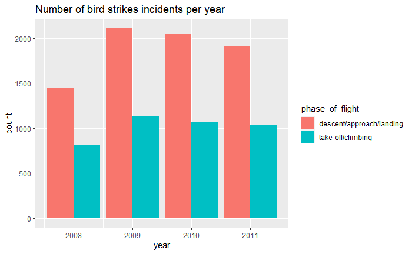

```r
ggplot(rdf, aes(x = year, y = count, fill = phase_of_flight)) +
geom_bar(stat = "identity", position = "dodge") + ggtitle("Number of bird strikes incidents per year")
```

## 9. Create a stored procedure in MySQL

This stored procedure is used to delete a record by ID.

```sql
CREATE PROCEDURE delete_by_id (IN id INT)
  BEGIN
    DELETE FROM record where record_id = id;
  END
```

Record 202701 exists before running the stored procedure.

```sql
SELECT record_id from record where record_id = 202701;
```

| record_id |
| --- |
| 202701 |

Run the stored procedure.

```sql
CALL delete_by_id(202701);
```

There is no records of this id after running the stored procedure.

```sql
SELECT record_id from record where record_id = 202701;
```

| record_id |
| --- |